# HW 7

Brian Hu (bth997)

4/6/2025

[Github](https://github.com/brianbevo/Homework-7)

## Problem 1

### Part A

In the dataset, there are 106 male participants and 111 female participants. Approximately 47% of the males folded their left arm on top, while around 42% of the females did the same.

### Part B

```r
diff_prop <- male_perc - female_perc
```

The observed difference in proportions between males and females who folded their left arm on top is approximately 0.05, with males showing a slightly higher proportion than females.

### Part D

If we were to repeatedly take new samples and compute confidence intervals each time, we would expect that approximately 95% of those intervals would capture the true difference in population proportions.

### Part E

The standard error quantifies the expected variability in the difference between male and female sample proportions regarding which arm is folded on top. It reflects how much the observed difference might fluctuate from the true population difference if we were to repeatedly sample the same population with the same sample sizes.

### Part F

The sampling distribution describes the probability distribution of the differences in sample proportions between males and females across many repetitions of the study. Elements that would vary from sample to sample include the individuals selected, the resulting sample proportions, and the calculated difference in proportions, while constants across these samples would be the the true population parameters, and the sample sizes.

### Part G

The Central Limit Theorem justifies using a normal approximation for the sampling distribution of the difference in sample proportions. According to the CLT if the sample sizes are sufficiently large the distribution of the sample proportion differences will approximate a normal distribution—even if the original population distribution is not normal.

### Part I

If this sampling process were repeated many times, sampling variability would cause different results. That could mean more or fewer individuals folding their arms a certain way in each sample. As a result, the sample proportions and the confidence intervals would vary. However, across all these repetitions, about 95% of the calculated 95% confidence intervals would be expected to contain the true difference in arm-folding proportions between males and females.

## Problem 2

### Part A

```
##
##  2-sample test for equality of proportions with continuity correction
##
## data:  total_votes out of total_calls
## X-squared = 39.597, df = 1, p-value = 3.122e-10
## alternative hypothesis: two.sided
## 95 percent confidence interval:
##  0.1411399 0.2659167
## sample estimates:
##    prop 1    prop 2
## 0.6477733 0.4442449
```

### i

```
## [1] "95% Confidence Interval Between GOTV calls and Voting in 1996:"
```

```
##
##  2-sample test for equality of proportions with continuity correction
##
## data:  v96_tab
## X-squared = 31.32, df = 1, p-value = 2.188e-08
## alternative hypothesis: two.sided
## 95 percent confidence interval:
##  0.1224366 0.2410506
## sample estimates:
##    prop 1    prop 2
## 0.4691930 0.2874494
```

```
## [1] "95% Confidence Interval Between Voting in 1996 and voting in 1998:"
```

```
##
##  2-sample test for equality of proportions with continuity correction
##
## data:  v96_v98_tab
## X-squared = 1832.4, df = 1, p-value < 2.2e-16
## alternative hypothesis: two.sided
## 95 percent confidence interval:
##  0.3932429 0.4275349
## sample estimates:
##    prop 1    prop 2
## 0.7706513 0.3602624
```

The voted1996 variable is a confounder when looking at the effect of GOTV calls on voting in 1998 because it’s linked to both getting a call and actually voting. People who voted in 1996 are more likely to get a GOTV call and also more likely to vote again in 1998. We can see this in the 95% confidence intervals from the prop.test, which don’t include zero—so there’s a clear connection. That’s why we need to account for past voting behavior when trying to figure out if the calls actually caused more people to vote.

### ii

```
## [1] "95% Confidence Interval Between GOTV calls and Major Party Registration:"
```

```
##
##  2-sample test for equality of proportions with continuity correction
##
## data:  major_call_tab
## X-squared = 3.8248, df = 1, p-value = 0.0505
## alternative hypothesis: two.sided
## 95 percent confidence interval:
##  0.004371919 0.109356458
## sample estimates:
##    prop 1    prop 2
## 0.2552448 0.1983806
```

```
## [1] "95% Confidence Interva Between Voting in 1998 and Major Party Registration:"
```

```
##
##  2-sample test for equality of proportions with continuity correction
##
## data:  major_v98_tab
## X-squared = 144.63, df = 1, p-value < 2.2e-16
## alternative hypothesis: two.sided
## 95 percent confidence interval:
##  0.08499419 0.11765163
## sample estimates:
##    prop 1    prop 2
## 0.2994303 0.1981074
```

The MAJORPTY variable is a confounder in the analysis of GOTV calls’ effect on voting behavior in 1998 because it is associated with both a higher chance of receiving a GOTV call and a higher probability of voting. This is shown by the 95% confidence intervals from the prop.test, which do not include zero, indicating that party registration affects both receiving a call and voting. Therefore, MAJORPTY must be considered when analyzing the causal relationship between GOTV calls and voting.

### iii

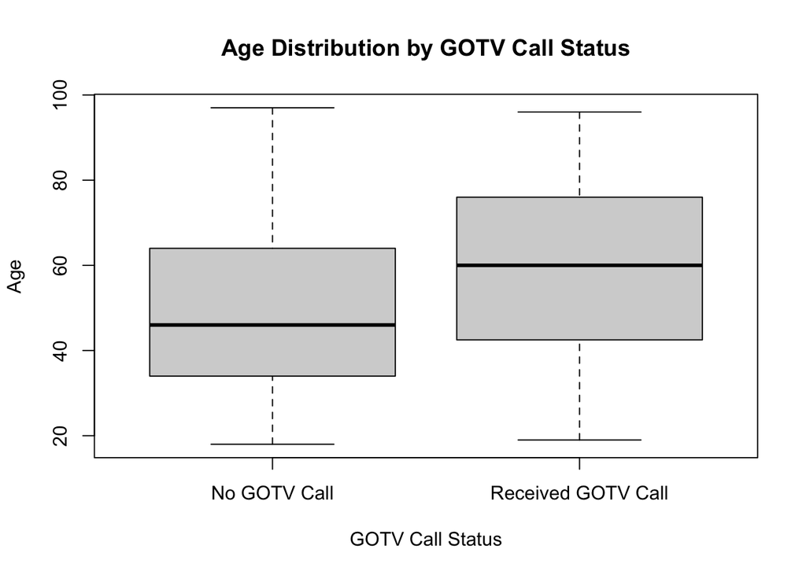

```
## [1] "95% Confidence Interval for Mean Age by GOTV Call Status:\n"
```

```
##
##  Welch Two Sample t-test
##
## data:  AGE by GOTV_call
## t = -6.9613, df = 256.33, p-value = 2.817e-11
## alternative hypothesis: true difference in means between group 0 and group 1 is not equal to 0
## 95 percent confidence interval:
##  -11.395051  -6.369644
## sample estimates:
## mean in group 0 mean in group 1
##        49.42534        58.30769
```

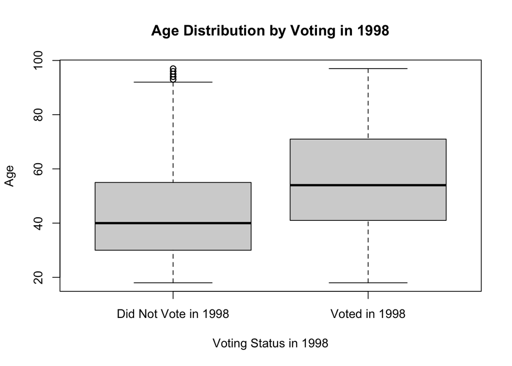

```
## [1] "\n95% Confidence Interval for Mean Age by Voting Status in 1998:\n"
```

```
##
##  Welch Two Sample t-test
##
## data:  AGE by voted1998
## t = -30.24, df = 10568, p-value < 2.2e-16
## alternative hypothesis: true difference in means between group 0 and group 1 is not equal to 0
## 95 percent confidence interval:
##  -11.182008  -9.820602
## sample estimates:
## mean in group 0 mean in group 1
##        44.91404        55.41535
```

The AGE variable is a confounder in the relationship between GOTV calls and voting in 1998 because it affects both receiving a call and voting. This is shown by boxplots with higher median ages and t-test confidence intervals for mean age that don’t include zero. Since age impacts both factors, it must be considered when analyzing the causal link between GOTV calls and voting.

### i

```
## [1] "Confidence intervals (Matched) for GOTV calls and 1996 voting behavior:\n"
```

```
##
##  2-sample test for equality of proportions without continuity correction
##
## data:  voting_1996_table
## X-squared = 1.9277e-29, df = 1, p-value = 1
## alternative hypothesis: two.sided
## 95 percent confidence interval:
##  -0.06182709  0.06182709
## sample estimates:
##    prop 1    prop 2
## 0.2874494 0.2874494
```

```
## [1] "\nConfidence intervals (Matched) for GOTV calls and major party registration:\n"
```

```
##
##  2-sample test for equality of proportions with continuity correction
##
## data:  party_affil_table
## X-squared = 0.013828, df = 1, p-value = 0.9064
## alternative hypothesis: two.sided
## 95 percent confidence interval:
##  -0.06247690  0.05114086
## sample estimates:
##    prop 1    prop 2
## 0.1927126 0.1983806
```

```
## [1] "\nConfidence intervals (Matched) for GOTV calls and mean age:\n"
```

```
##
##  Welch Two Sample t-test
##
## data:  matched_df$AGE by matched_df$GOTV_call
## t = -0.02987, df = 350.55, p-value = 0.9762
## alternative hypothesis: true difference in means between group 0 and group 1 is not equal to 0
## 95 percent confidence interval:
##  -2.760374  2.677783
## sample estimates:
## mean in group 0 mean in group 1
##        58.26640        58.30769
```

The 95% confidence intervals for the confounding variables of voting in 1996, major party registration, and age all contain zero, indicating that the dataset is balanced between groups receiving or not receiving a call, with a ratio of 5 control cases per treated case.